# Lab 1

In this lab, we create, load and display network data. Parts of this lab are based on McFarland, Daniel, Solomon Messing, Mike Nowak, and Sean Westwood. 2010. “Social Network Analysis Labs in R.” Stanford University.

## Setup

We need to use the “igraph”, “network” and “sna” packages.

```
library("sand")
library("igraph")
```

This is data collected from the managers of a high-tec company. Each manager was asked to whom do you go to for advice and who is your friend, to whom do you report was taken from company documents. In addition attribute information was collected. Krackhardt D. (1987). Cognitive social structures. Social Networks, 9, 104-134.

### Loading the data

The data is stored in four separate files. The edgelists are in the form: v1 v2 wt

where v1 and v2 are nodes and wt is 1 if there is an edge between these two vertices and 0 if there is not. The edgelists are complete – all possible edges are represented.

There are four attributes for each manager: age in years, tenure (time worked at the company) in years, level in the corporate hierarchy (1=highest=CEO), and department.

```r
setwd("C:/Users/TG/Documents/GitHub/Social Network Analysis/lab1/lab1")
kr.advice<-read.table("krack-advice-edges.txt")
kr.friend<-read.table("krack-friend-edges.txt")
kr.reports<-read.table("krack-reports-edges.txt")
kr.attrs<-read.csv("krack-attrs.csv")
```

### Consolidating the data

Consolidate the data in a data frame and remove absent edges. The data frame should have columns “ego”, “alter”, “advice”, “friend”, “reportsTo”.

```r
# Create a data frame
kr.df<-data.frame(ego=kr.advice[,1],alter=kr.advice[,2],advice=kr.advice[,3],friend=kr.friend[,3],reports=kr.reports[,3])
# Get rid of the absent edges
kr.nz<-kr.df[kr.df$advice+kr.df$friend+kr.df$reports>0,]
```

### Convert to a graph and add attributes to edges and vertices

```r
# Convert to network using edgelist
kr.net <- graph.edgelist(cbind(kr.nz$ego,kr.nz$alter),directed=TRUE)
# Set edge attributes
E(kr.net)$advice<-kr.nz$advice
E(kr.net)$friend<-kr.nz$friend
E(kr.net)$reports<-kr.nz$reports
# Set vertex attributes

V(kr.net)$age<-kr.attrs$AGE
V(kr.net)$tenure<-kr.attrs$TENURE
V(kr.net)$dept<-kr.attrs$DEPT
V(kr.net)$level<-kr.attrs$LEVEL
```

### Create subnetworks based on types of edges

```r
# Divide by edge types: advice
advice.net<-delete.edges(kr.net,which(E(kr.net)$advice==0))
# Divide by edge types: friend
friend.net<-delete.edges(kr.net,which(E(kr.net)$friend==0))
# Divide by edge types: reportsTo
reports.net<-delete.edges(kr.net,which(E(kr.net)$reports==0))
```

We will show all of the networks together in a single figure.

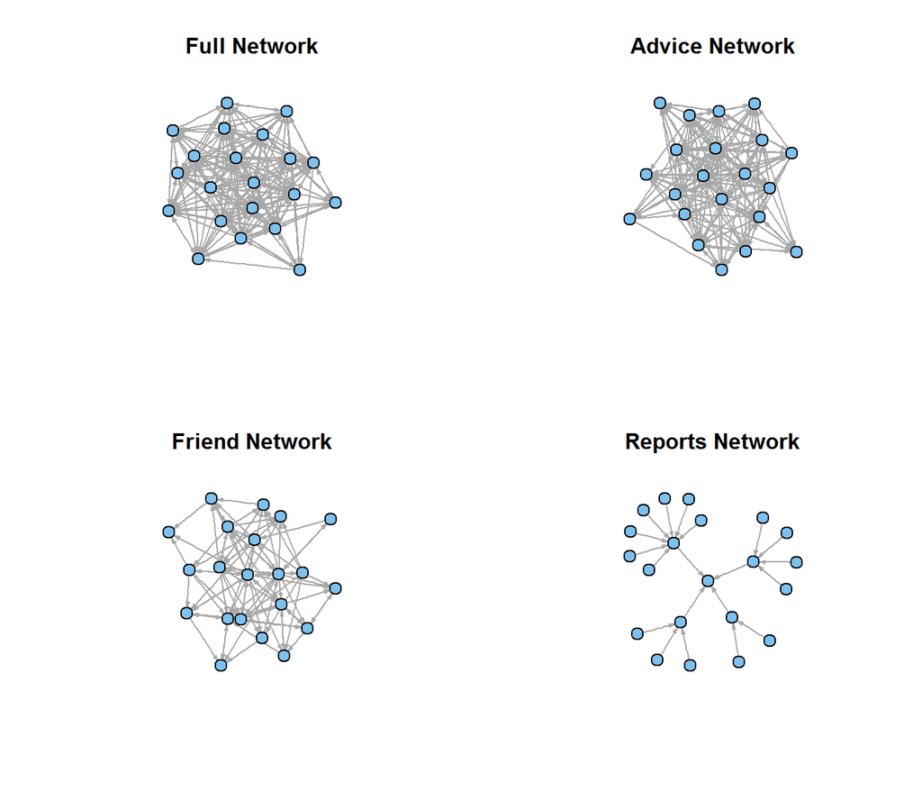

```r
# Show all of the networks together in a single figure.
# Creates a 2x2 array of plots
par(mfrow=c(2,2))
plot(kr.net,vertex.label=NA,edge.arrow.size=0.2,main="Full Network")
plot(advice.net,vertex.label=NA,edge.arrow.size=0.2,main="Advice Network")
plot(friend.net,vertex.label=NA,edge.arrow.size=0.2,main="Friend Network")
plot(reports.net,vertex.label=NA,edge.arrow.size=0.2,main="Reports Network")
```

```r
# Goes back to 1 plot at a time
par(mfrow=c(1,1))
```

Do the same thing but output to PDF.

```r
pdf("lab1-all-nets.pdf")
par(mfrow=c(2,2))

plot(kr.net,vertex.label=NA,edge.arrow.size=0.2,main="Full Network")
plot(advice.net,vertex.label=NA,edge.arrow.size=0.2,main="Advice Network")
plot(friend.net,vertex.label=NA,edge.arrow.size=0.2,main="Friend Network")
plot(reports.net,vertex.label=NA,edge.arrow.size=0.2,main="Reports Network")
# Goes back to 1 plot at a time
par(mfrow=c(1,1))
# Closes the file
dev.off()
```

### Advice in-degree

It seems likely that people who are at a company longer might be asked for advice more often. Let’s test this hypothesis. The more fellow managers list a person as a source of advice, the higher that person’s in-degree.

First, we’ll plot the advice network, sizing the nodes by tenure.

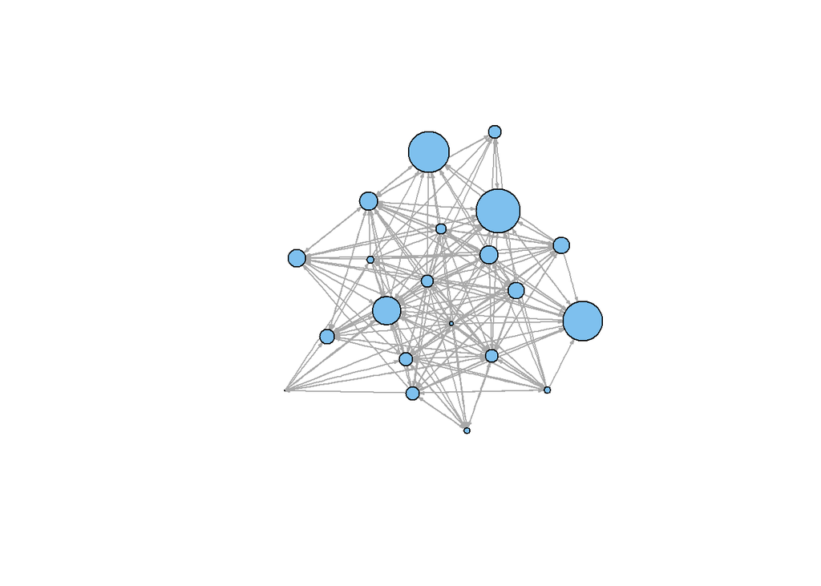

```r
# Plot the advice network, size the nodes by tenure.
plot(advice.net,vertex.size=V(advice.net)$tenure,vertex.label=NA,edge.arrow.size=0.2)
```

```r
# Collect the in-degree data for the advice network
advice.ind<-degree(advice.net,mode='in')
#histogram of indegreees
```

Then we’ll look at a regression model.

```r
# Regression on this variable
advice.lm<-lm(advice.ind~V(advice.net)$tenure)
# See the results
summary(advice.lm)
```

```
##
## Call:
## lm(formula = advice.ind ~ V(advice.net)$tenure)
##
## Residuals:
##    Min     1Q Median     3Q    Max
## -4.323 -2.231 -1.026  1.066  6.803
##
## Coefficients:
##                      Estimate Std. Error t value Pr(>|t|)
## (Intercept)           5.82633    1.37798   4.228 0.000455 ***
## V(advice.net)$tenure  0.27424    0.09755   2.811 0.011148 *
## ---
## Signif. codes:  0 '***' 0.001 '**' 0.01 '*' 0.05 '.' 0.1 ' ' 1
##
## Residual standard error: 3.507 on 19 degrees of freedom
## Multiple R-squared:  0.2938, Adjusted R-squared:  0.2566
## F-statistic: 7.903 on 1 and 19 DF,  p-value: 0.01115
```

To check assumptions, we can look at the residuals:

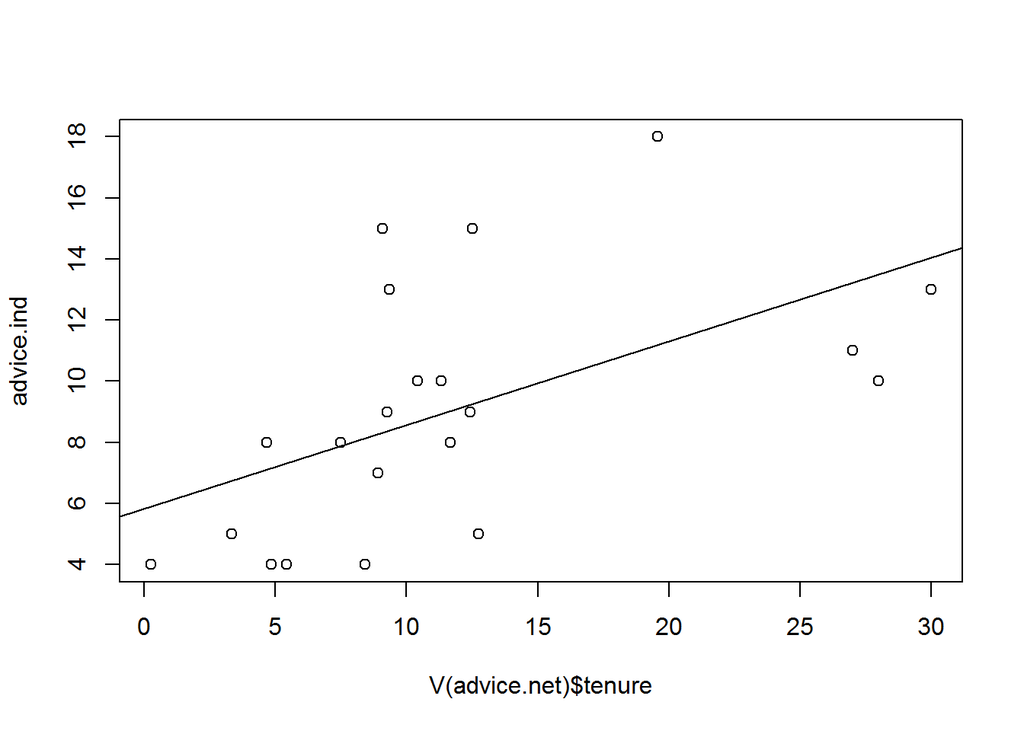

```r
# Create a plot of in-degree vs tenure
plot(V(advice.net)$tenure,advice.ind)
# Add the regression line to the plot
abline(advice.lm)
```

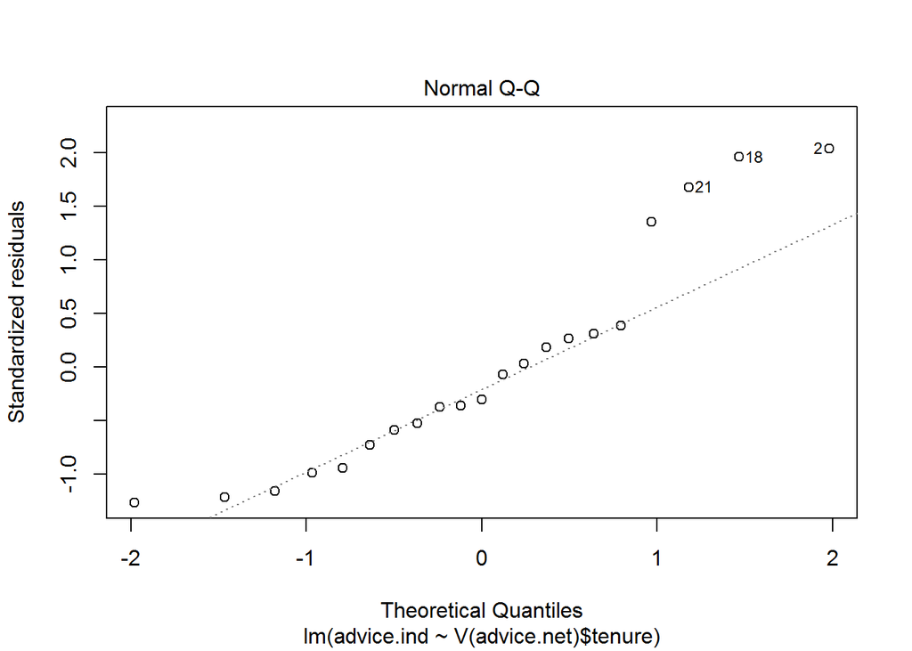

```r
plot(advice.lm,which=2)
```

What do we learn from this?

Generally, there is the trend we would expect, but there are some major outliers who get asked for advice more than their experience alone would suggest.

### More visualizations

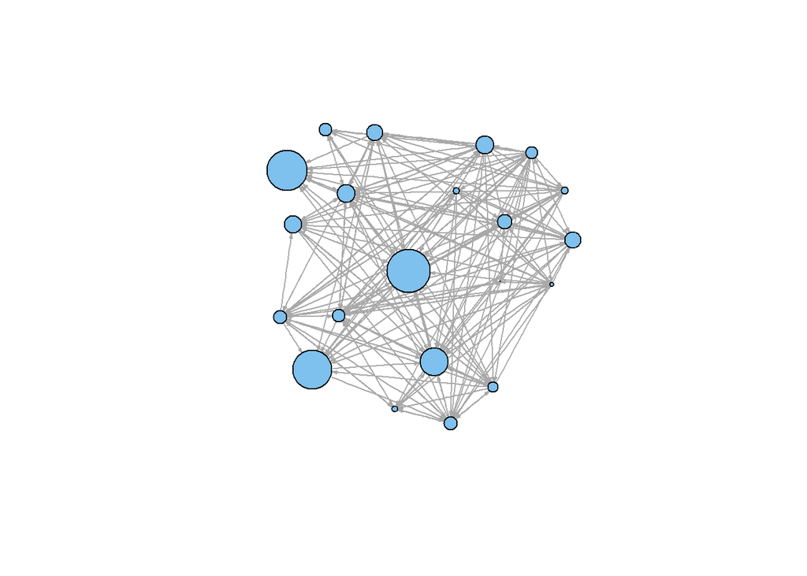

```r
# Compute the reportsTo layout
reports.layout<-layout.fruchterman.reingold(reports.net)


# Plot, sizing by tenure
plot(advice.net,vertex.size=V(advice.net)$tenure,vertex.label=NA,edge.arrow.size=0.2,layout=reports.layout)
```

For our final plot, we will display all of the networks overlayed with different edge colors. For this, we’ll display the original networks, but we need color information mapped to the different edge types. Note the same edge colors will overwrite each other: no simple solution for this.

```r
# Set up some edge colors (use transparency)
edge.colors<- c(rgb(1,0,0,.5), rgb(0,0,1,.5), rgb(0,0,0,0.75))

# Create an edge attribute called "color" and set it correctly.
E(kr.net)[E(kr.net)$advice==1]$color<-edge.colors[1]
E(kr.net)[E(kr.net)$friend==1]$color<-edge.colors[2]
E(kr.net)[E(kr.net)$reports==1]$color<-edge.colors[3]
```

We’ll plot the whole network and include a legend for ease of understanding.

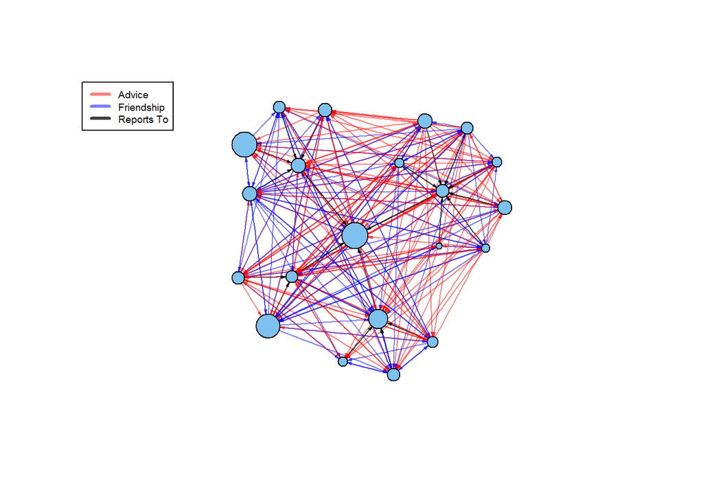

```r
# Plot, sizing by tenure
plot(kr.net,vertex.size=(V(kr.net)$tenure/2)+5,vertex.label=NA,edge.arrow.size=0.2,layout=reports.layout,edge.color=E(kr.net)$color)
# Add a legend to explain the colors
legend("topleft",
       legend = c('Advice',
                  'Friendship',
                  'Reports To'),
       col = edge.colors,
       lty=1, lwd=3,
       cex = 0.6)
```